# R-Script for Pre-Registration Experiment 1a: Direct evalautive ratings

## (3) Alternative way of approaching H1 (use “CS ratings” as a predictor, control for categories)

### Hypothesis 1:

Generalization towards novel stimuli is wider in the “many” condition than in the “one” condition.

CS ratings as the continuous predictor. GS as the outcome variable. Both z-standardized. Condition as the between-subjects variable.

H1a: *significant interaction CS and condition* -> predictive value of CS to predict GS ratings depends on the different conditions -> slope is steeper for “many” than for “one”

### plot prediction of “GS” with “CS”, controlling for categories

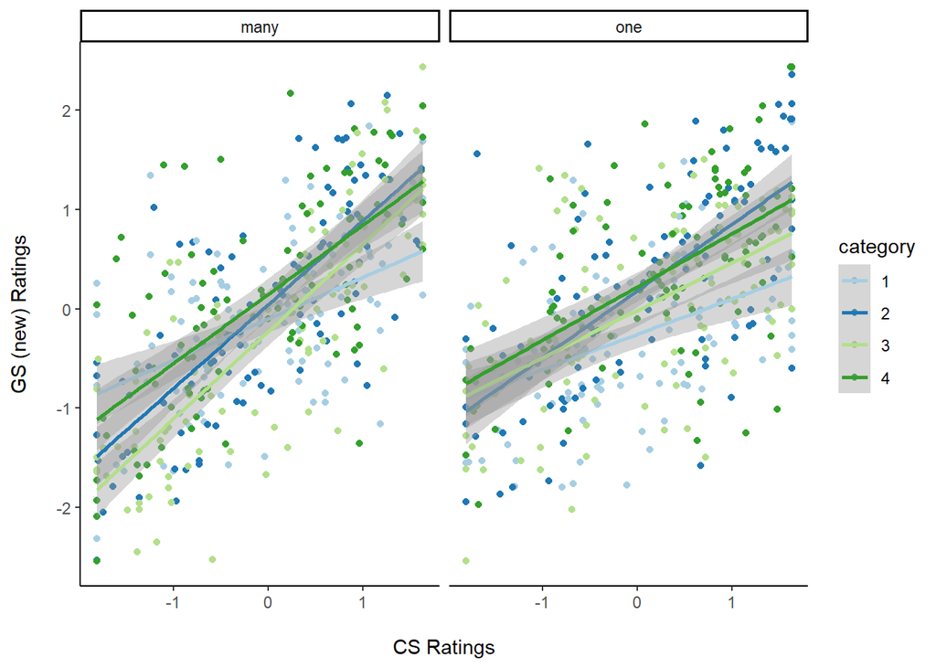